# Assignment 5: Linear Regression Analysis of Car Price Dataset

Danny Godbout

July 26, 2016

### Final Model Summary

The final model achieves an R-squared value of 0.86 using engine size, curb weight, and city mpg to predict price. For this model, log transformations of engine size and price are used.

A review of the model coefficients shows that all three independent variables are statistically significant. In addition, looking at the coefficient estimate and scale of the curb weight variable shows that this is the most influential variable on price.

Subsequent tabs show assumption testing and model iteration + validation activities leading to this model.

```
Call:
lm(formula = model.formula, data = auto.data.no.outliers)

Residuals:
     Min       1Q   Median       3Q      Max
-0.43109 -0.10844 -0.00503  0.09660  0.51868

Coefficients:
                  Estimate Std. Error t value Pr(>|t|)
(Intercept)      6.096e+00  5.002e-01  12.189  < 2e-16 ***
log.engine.size  4.369e-01  1.187e-01   3.682 0.000302 ***
curb.weight      5.526e-04  6.245e-05   8.849 6.46e-16 ***
city.mpg        -1.077e-02  3.421e-03  -3.147 0.001917 **
---
Signif. codes:  0 '***' 0.001 '**' 0.01 '*' 0.05 '.' 0.1 ' ' 1

Residual standard error: 0.1848 on 188 degrees of freedom
Multiple R-squared:  0.8621,    Adjusted R-squared:  0.8599
F-statistic: 391.7 on 3 and 188 DF,  p-value: < 2.2e-16
```

```
   log.price      log.engine.size  curb.weight      city.mpg
 Min.   : 8.541   Min.   :4.111   Min.   :1488   Min.   :13.00
 1st Qu.: 8.956   1st Qu.:4.585   1st Qu.:2145   1st Qu.:19.50
 Median : 9.235   Median :4.787   Median :2414   Median :25.00
 Mean   : 9.350   Mean   :4.810   Mean   :2559   Mean   :25.37
 3rd Qu.: 9.712   3rd Qu.:4.980   3rd Qu.:2944   3rd Qu.:30.00
 Max.   :10.723   Max.   :5.787   Max.   :4066   Max.   :49.00
```

### Variable Transformations

A review of the Q-Q plots for the independent and dependent variables shows deviations from normality for both the price and engine size variables. Log transformations of these variables improves the Q-Q plots.

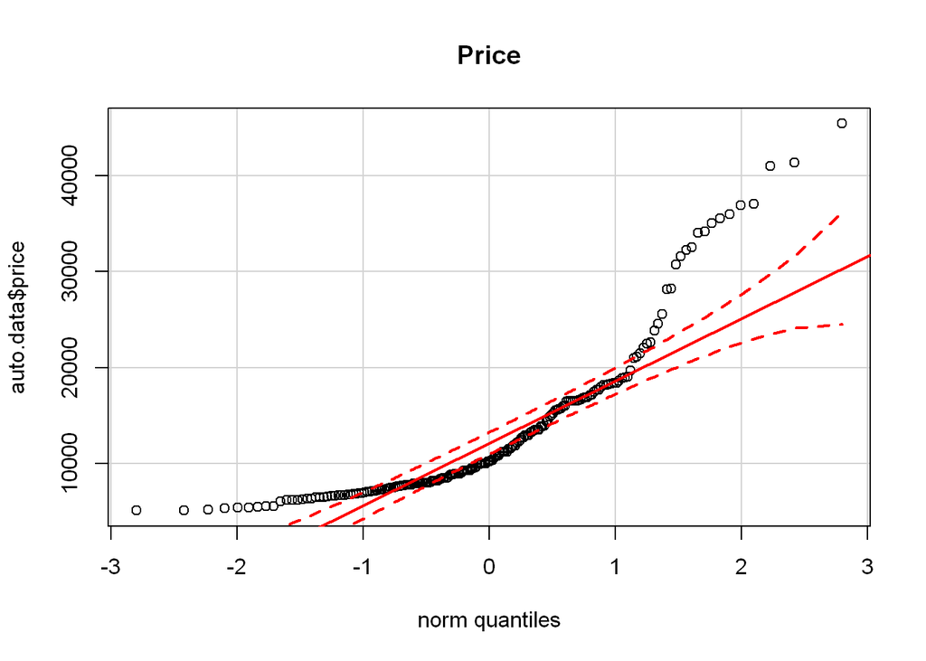

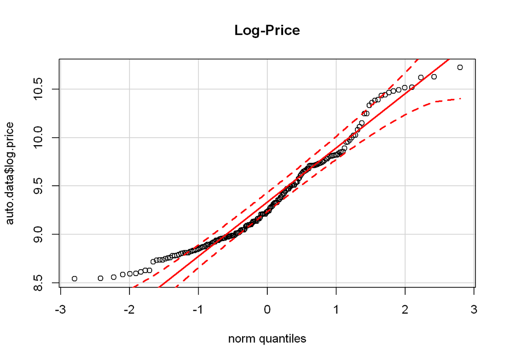

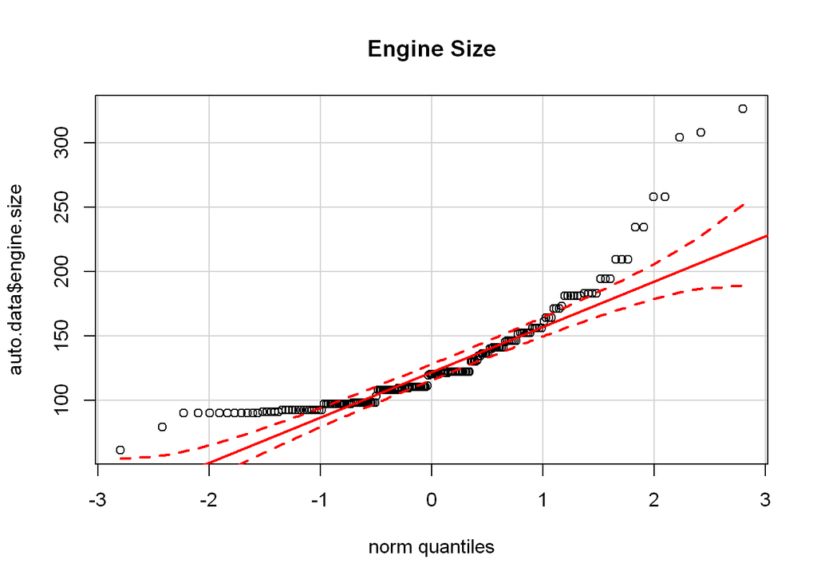

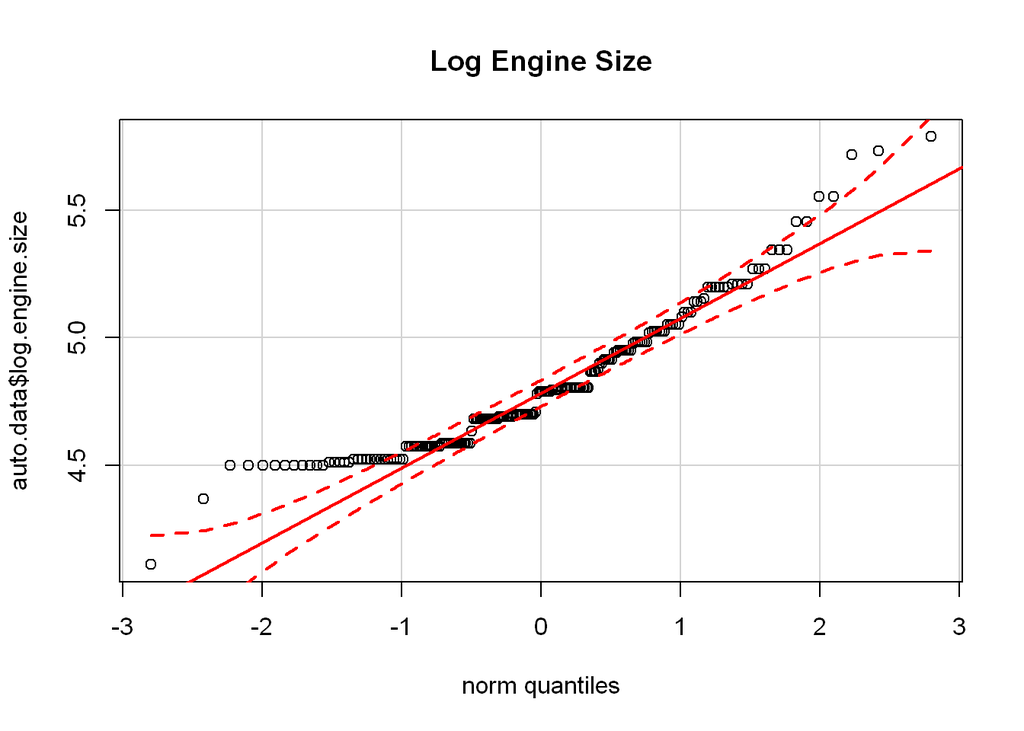

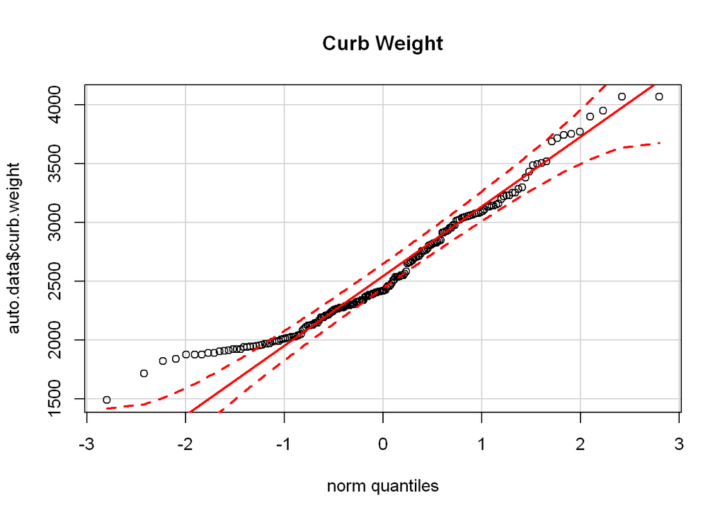

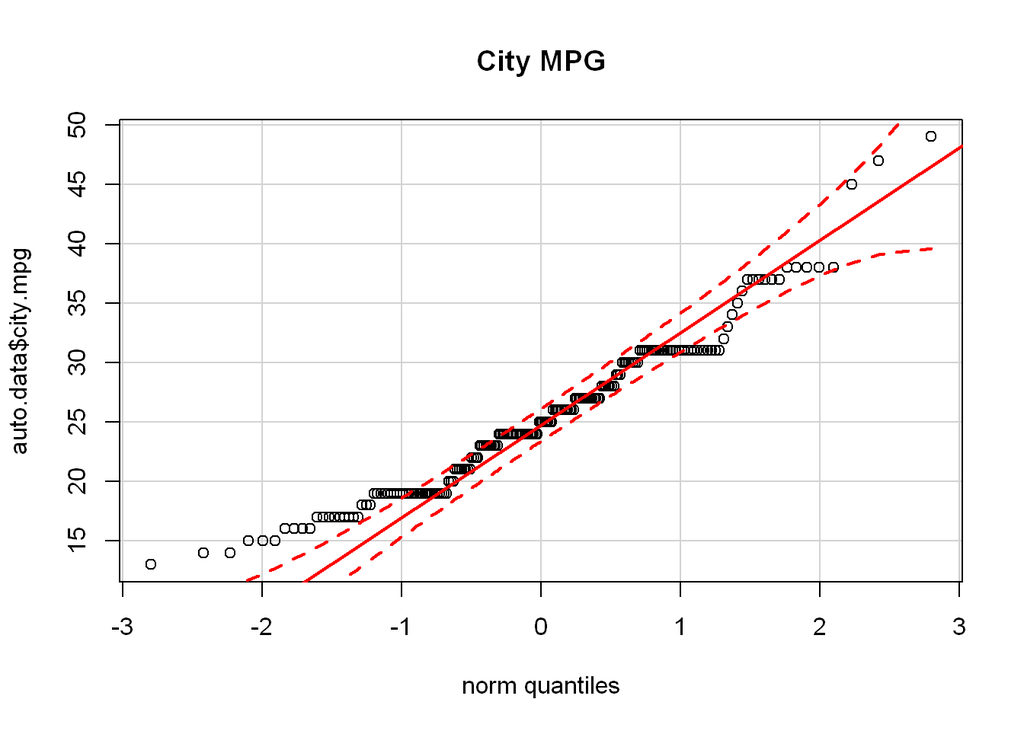

Testing the linearity of the relationships between the independent variables (log engine size, curb weight, city mpg) and the dependent variable (log price) shows no obvious non-linearities.

[figure not shown]

[figure not shown]

[figure not shown]

### Model Building

The initial model achieves an R-squared value of 0.84 using engine size, curb weight, and city mpg to predict price. For this model, log transformations of engine size and price are used.

A review of the model coefficients shows that all three independent variables are statistically significant. In addition, looking at the coefficient estimate and scale of the curb weight variable shows that this is the most influential variable on price.

```
Call:
lm(formula = model.formula, data = auto.data)

Residuals:
     Min       1Q   Median       3Q      Max
-0.46101 -0.11779 -0.00326  0.09511  0.65035

Coefficients:
                  Estimate Std. Error t value Pr(>|t|)
(Intercept)      5.346e+00  5.254e-01  10.176  < 2e-16 ***
log.engine.size  6.716e-01  1.216e-01   5.525 1.07e-07 ***
curb.weight      4.303e-04  6.405e-05   6.719 2.05e-10 ***
city.mpg        -1.293e-02  3.689e-03  -3.504  0.00057 ***
---
Signif. codes:  0 '***' 0.001 '**' 0.01 '*' 0.05 '.' 0.1 ' ' 1

Residual standard error: 0.2005 on 191 degrees of freedom
Multiple R-squared:  0.8473,    Adjusted R-squared:  0.8449
F-statistic: 353.2 on 3 and 191 DF,  p-value: < 2.2e-16
```

```
   log.price      log.engine.size  curb.weight      city.mpg
 Min.   : 8.541   Min.   :4.111   Min.   :1488   Min.   :13.00
 1st Qu.: 8.956   1st Qu.:4.585   1st Qu.:2145   1st Qu.:19.50
 Median : 9.235   Median :4.787   Median :2414   Median :25.00
 Mean   : 9.350   Mean   :4.810   Mean   :2559   Mean   :25.37
 3rd Qu.: 9.712   3rd Qu.:4.980   3rd Qu.:2944   3rd Qu.:30.00
 Max.   :10.723   Max.   :5.787   Max.   :4066   Max.   :49.00
```

### Model Performance

The initial linear model returns an R-square of 0.847 and RMSE of 0.198.

```
[1] "R-squared: 0.847"
```

```
[1] "RMSE: 0.198"
```

Verifying the normality of the residuals returns a Shapiro-Wilks test result p < 0.05, indicating some non-normality. This is also seen in the Q-Q plot for the model residuals. The Residuals-Fitted plot does not show obvious heteroscedasticity. The leverage plot shows some points with moderate leverage, but no points of highly concerning leverage & high residuals that may dramatically skew the model.

```
    Shapiro-Wilk normality test

data:  auto.data$residuals
W = 0.98143, p-value = 0.01097
```

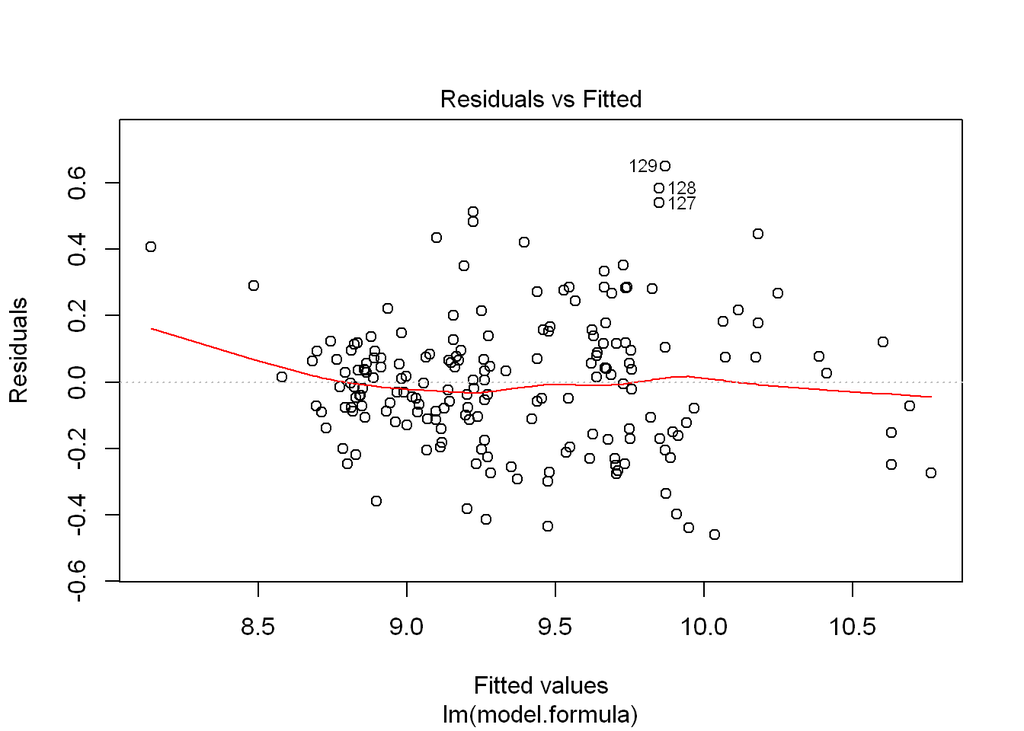

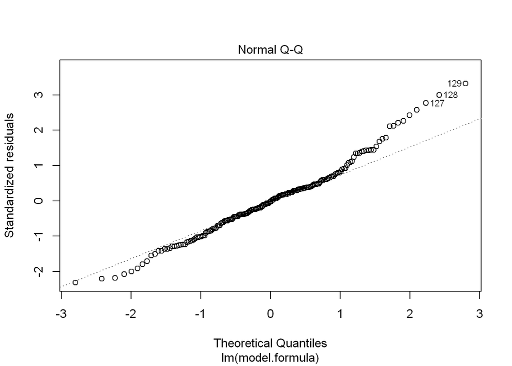

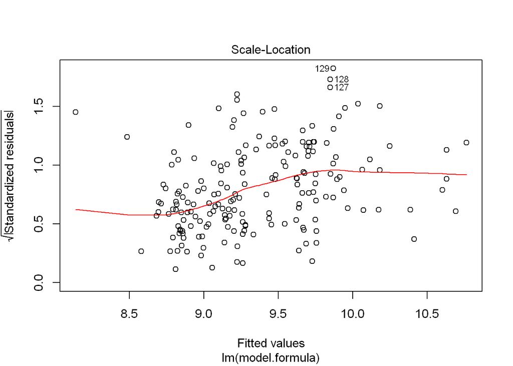

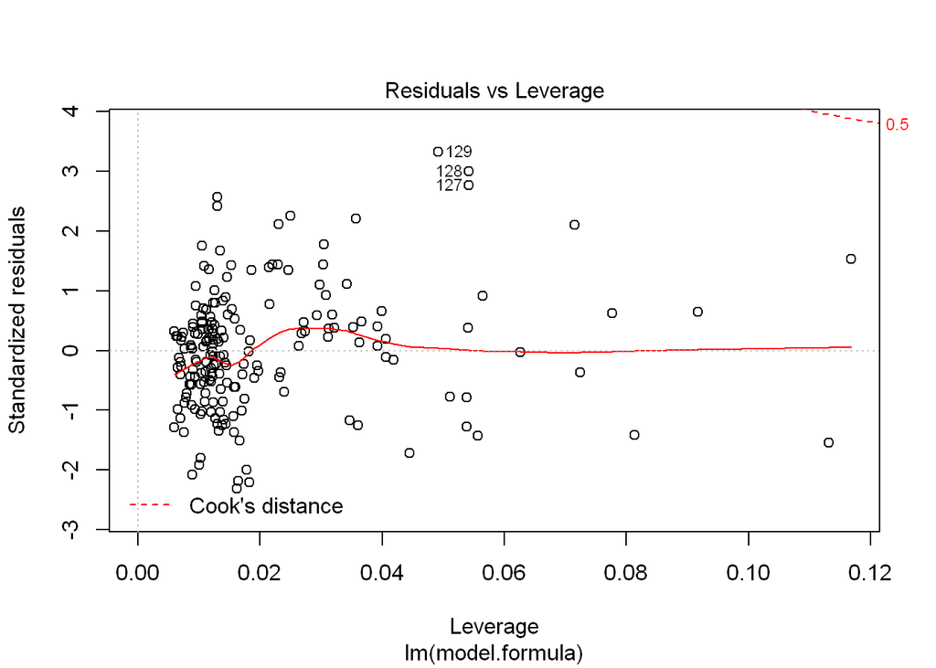

Removing the outliers identified in the Q-Q plot for the initial model, we see a noticeable improvement in the R-square value (0.862) and improves the normality test results on the residuals (p > 0.05).

```
Call:
lm(formula = model.formula, data = auto.data.no.outliers)

Residuals:
     Min       1Q   Median       3Q      Max
-0.43109 -0.10844 -0.00503  0.09660  0.51868

Coefficients:
                  Estimate Std. Error t value Pr(>|t|)
(Intercept)      6.096e+00  5.002e-01  12.189  < 2e-16 ***
log.engine.size  4.369e-01  1.187e-01   3.682 0.000302 ***
curb.weight      5.526e-04  6.245e-05   8.849 6.46e-16 ***
city.mpg        -1.077e-02  3.421e-03  -3.147 0.001917 **
---
Signif. codes:  0 '***' 0.001 '**' 0.01 '*' 0.05 '.' 0.1 ' ' 1

Residual standard error: 0.1848 on 188 degrees of freedom
Multiple R-squared:  0.8621,    Adjusted R-squared:  0.8599
F-statistic: 391.7 on 3 and 188 DF,  p-value: < 2.2e-16
```

```
    Shapiro-Wilk normality test

data:  auto.data.no.outliers$residuals
W = 0.98697, p-value = 0.07425
```

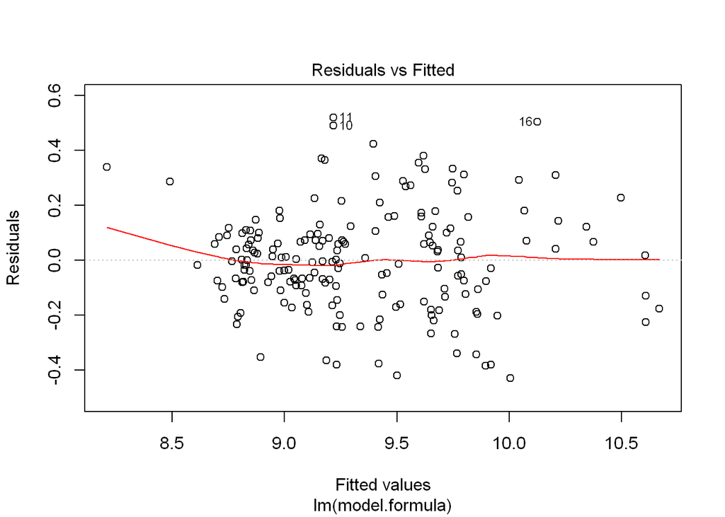

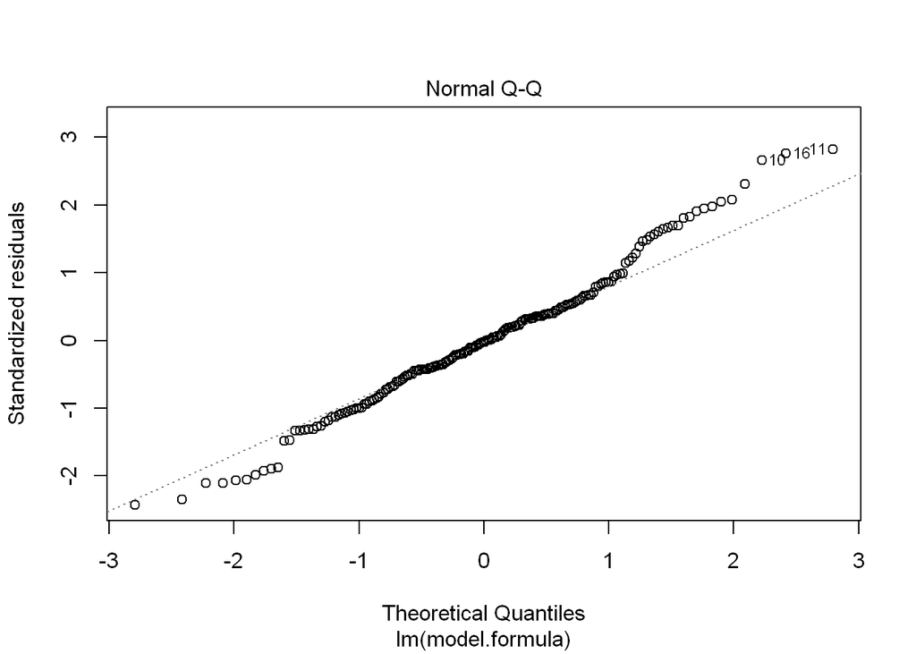

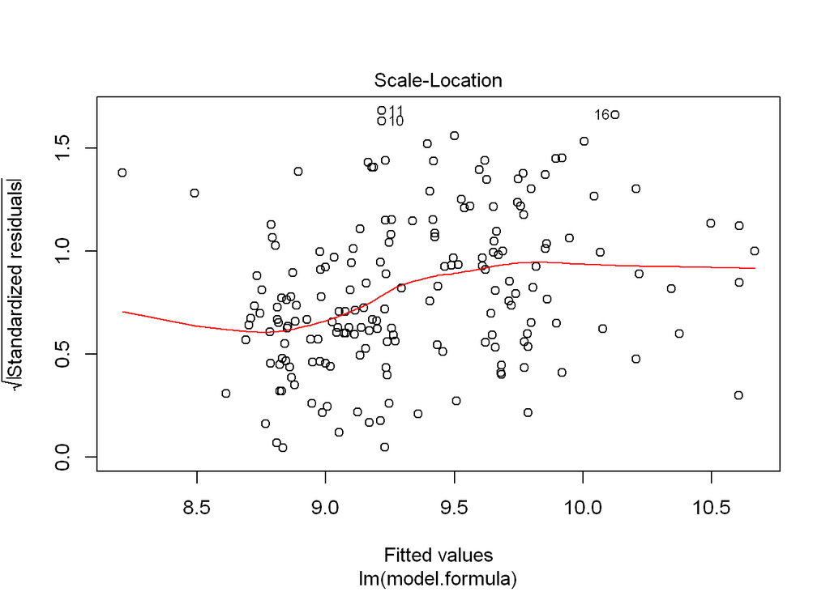

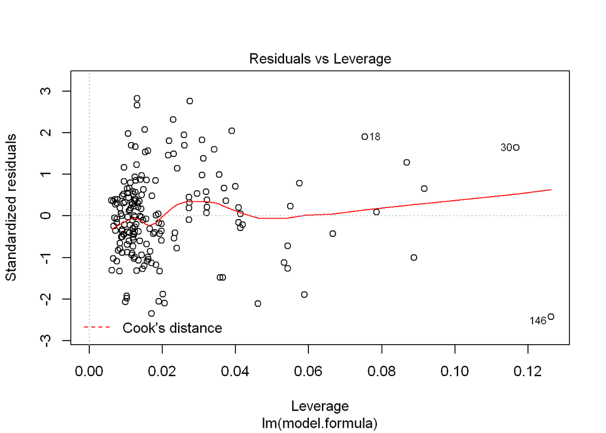